# 3rd/4th Down Converter

In order to assess a team’s ability to convert for a first down in situations they need to, we will build a few machine learning models to predict the probability a team will convert for a first down on 3rd down or 4th down (if they go for it).

The overall goal is to measure how effective teams are in 3rd/4th down situations compared to what is expected. We will use the model to evaluate the probability a team converts for a first down and compare that to the actual play result. This will let us see how much a team performed over (or under) the expected play result.

For example, if a team has a probability of 90% to convert a first down, and they do, they beat expectations by 10%. If they fail, they are under expectations by 90%.

To measure this, we will calculate the field “First Down Over Expected” once the models are created.

This dataset is built using the framework created by Ben Baldwin. For more information on that, see this code: https://github.com/guga31bb/fourth_calculator/blob/main/scripts/_go_for_it_model.R

## Setting up the Model

First things first, we need to load all the intended libraries and our data.

The “colors” table is a custom table added to the nflfastR database, using nflfastR data.

IE:

```
dbWriteTable(connection, name = "team_color_logos", value = nflfastR::teams_colors_logos, row.names = FALSE)
```

```r
rm(list = ls())

library(DBI)
library(RSQLite)
library(tidyverse)
library(ggplot2)
library(ggimage)
library(ggrepel)
library(h2o)
library(zoo)
library(corrplot)

theme_set(  theme_classic() +
              theme(axis.title = element_text(size = 12),
                    axis.text = element_text(size = 8),
                    plot.title = element_text(size = 13, hjust = 0.5),
                    plot.subtitle = element_text(size = 8, hjust = 0.5),
                    plot.caption = element_text(size = 7),
                    legend.position = "none")
            )



source('https://raw.githubusercontent.com/mrcaseb/nflfastR/master/R/helper_add_nflscrapr_mutations.R')

#### Connect to nflfastR database ####
path <- "/Users/joeybloom/Desktop/NFLScrapR/database/pbp_db"

connection <- dbConnect(SQLite(), path)

pbp_db <- tbl(connection, "nflfastR_pbp")
colors <- tbl(connection,"team_color_logos")
```

## Get Prediction Data

We will start by grabbing all rush and pass plays that occurred on 3rd or 4th down.

In order to make it easier to evaluate punt situations later on, we are going to include punt attempts when pulling data. These will be filtered out when modeling begins.

The code in the link above was used as a template for this section.

```r
## Pull data for 3rd/4th down pass/rush attempts
last_play_drive_t1 <- pbp_db %>%
  ## src - @benbaldwin
  filter(
    down %in% c(3,4),
    qb_kneel == 0,
    rush == 1 | pass == 1 | punt_attempt == 1,
    !is.na(posteam),
    !is.na(yardline_100),
    !is.na(score_differential),
    season >= 2006
  ) %>%
  make_model_mutations()


#### Attributes from 3rd/4th down to use as input ####
last_play_drive_t2 <- last_play_drive_t1 %>%
  mutate(yards_gained =

           # src - @benbaldwin
           # we need a way to account for defensive penalties that give auto first downs
           # hacky "solution" is saying here that a penalty that gives a first down goes for the yards to go
           # unless the actual penalty yardage is higher

           # the drawback is that a defensive holding on eg 4th and 8 is coded as an 8 yard gain
           # the alternative is to estimate a separate model for penalties or have their own category
           # but first down penalties on 4th and long are very rare:
           # https://twitter.com/benbbaldwin/status/1322530446371074050

           case_when(
             first_down_penalty == 1 & penalty_yards < ydstogo ~ ydstogo,
             first_down_penalty == 1 & penalty_yards >= ydstogo ~ penalty_yards,
             TRUE ~ yards_gained
           ),

         # truncate to make model training easier -- add capping at -10 and 65 yards (src - @benbaldwin) #
         yards_gained = if_else(yards_gained < -10, -10, yards_gained),
         yards_gained = if_else(yards_gained > 65, 65, yards_gained),

         # Vegas expected points to be scored (src - @benbaldwin) #
         home_total = (spread_line + total_line) / 2,
         away_total = (total_line - spread_line) / 2,

         # Determine total/spread for possession team (src - @benbaldwin) #
         posteam_total = if_else(posteam == home_team, home_total, away_total),
         posteam_spread = dplyr::if_else(posteam == home_team, spread_line, -1 * spread_line)
  ) %>%

  # look at when an actual play is run or a defensive penalty gives a first down (src - @benbaldwin)
  filter(play_type_nfl %in% c("RUSH", "PASS", "SACK") | first_down_penalty == 1) %>%

  # Select fields for training #
  select(

    ## Match Back/ID Fields
    play_id,game_id,posteam,season,

    ## Prediction Field
    first_down,

    ## Play Result Fields
    yards_gained,air_yards,yards_after_catch,epa,rush,pass,

    ## @benbaldwin Selected Fields ##
    down,
    ydstogo,
    yardline_100,
    outdoors, retractable, dome,
    posteam_spread, total_line, posteam_total,

    ## JB Selected Fields ##
    era,
    week,yardline_100,game_seconds_remaining,season_type,
    qtr,wp,ep,ydstogo,shotgun,no_huddle,score_differential,
    desc
  ) %>%
  left_join(
    colors, by=c('posteam' = 'team_abbr')
  )
```

Let’s check out how many first downs actually occurred among the plays pulled:

```r
last_play_drive_t2 %>%
  filter(rush == 1 | pass == 1) %>%
  count(first_down) %>%
  collect() %>%
  select(first_down,n) %>%
  knitr::kable()
```

| first_down | n |
| --- | --- |
| 0 | 44552 |
| 1 | 34021 |

More plays result in a failed conversion than do. Teams are converting about 43% of the time on third and fourth down.

Let’s check this out by each individual down.

```r
last_play_drive_t2 %>%
  filter(rush == 1 | pass == 1) %>%
  count(down,first_down) %>%
  collect() %>%
  select(down,first_down,n) %>%
  knitr::kable()
```

| down | first_down | n |
| --- | --- | --- |
| 3 | 0 | 41914 |
| 3 | 1 | 31148 |
| 4 | 0 | 2638 |
| 4 | 1 | 2873 |

Though there are a lot less plays occurring on 4th down, from 2006 - 2020, teams are actually converting about 52% of the time, compared to 42% of the time on 3rd down.

## Moving Game Averages and Totals

As a next step, we will calculate moving averages and cumulative sums for rush and pass plays. This will create features such as “average yards per rush” or “total yards gained rushing” for the model. This lets us take into account a team’s in-game performance.

To do this, we take several variables and create moving averages / cumulative sums grouped by game and possesion team.

##### Passing Stats

```r
## Pass Play Fields ##
cum_fields <- c('epa','yards_gained','air_yards','yards_after_catch')

p_game_summary_t1 <- pbp_db %>%
  filter(qb_kneel == 0,
         pass == 1,
         !is.na(posteam),
         !is.na(yardline_100),
         !is.na(score_differential),
         season >= 2006 ) %>%
  select(season,week,desc,pass,posteam,game_id,play_id,epa,yards_gained,air_yards,yards_after_catch) %>%
  collect()

p_game_summary_t2 <-  p_game_summary_t1 %>%
  #filter(season == 2020 ) %>%   ## FOR TEST - Below function runs longer with lots of data ##
  group_by(game_id,posteam)


## Calculate moving average/cumulative total
p_game_summary_t3 <- p_game_summary_t2 %>%
  mutate_at(
    vars(cum_fields),funs(## Cumulative/Moving Average ##
                          "cum_game_avg_PASS"= lag(rollapply(.,seq_along(p_game_summary_t2), mean,align='right',fill=NA)),

                          ## Cumulative Sum ##
                          "cum_game_tot_PASS"= lag(cumsum(.))
    )
  )


## View Chicago Bears Data
p_game_summary_t3 %>%
  select(posteam,season,week,desc,yards_gained,yards_gained_cum_game_avg_PASS,yards_gained_cum_game_tot_PASS,
                             air_yards,air_yards_cum_game_avg_PASS,air_yards_cum_game_tot_PASS,
                             yards_after_catch,yards_after_catch_cum_game_avg_PASS,yards_after_catch_cum_game_tot_PASS,
                             epa,epa_cum_game_avg_PASS,epa_cum_game_tot_PASS) %>%
  filter(posteam=='CHI', season == 2020, week == 1) %>%
  head(5) %>%
  knitr::kable()
```

| game_id | posteam | season | week | desc | yards_gained | yards_gained_cum_game_avg_PASS | yards_gained_cum_game_tot_PASS | air_yards | air_yards_cum_game_avg_PASS | air_yards_cum_game_tot_PASS | yards_after_catch | yards_after_catch_cum_game_avg_PASS | yards_after_catch_cum_game_tot_PASS | epa | epa_cum_game_avg_PASS | epa_cum_game_tot_PASS |
| --- | --- | --- | --- | --- | --- | --- | --- | --- | --- | --- | --- | --- | --- | --- | --- | --- |
| 2020_01_CHI_DET | CHI | 2020 | 1 | (11:58) 10-M.Trubisky pass incomplete short right to 80-J.Graham [52-C.Jones]. | 0 | NA | NA | -1 | NA | NA | NA | NA | NA | -0.6427499 | NA | NA |
| 2020_01_CHI_DET | CHI | 2020 | 1 | (11:53) (Shotgun) 10-M.Trubisky pass short left to 12-A.Robinson pushed ob at CHI 38 for 13 yards (24-A.Oruwariye). | 13 | 0.000000 | 0 | 3 | -1.000000 | -1 | 10 | NA | NA | 1.3760885 | -0.6427499 | -0.6427499 |
| 2020_01_CHI_DET | CHI | 2020 | 1 | (10:33) 10-M.Trubisky pass short right to 12-A.Robinson to DET 37 for 12 yards (25-W.Harris). | 12 | 6.500000 | 13 | 12 | 1.000000 | 2 | 0 | NA | NA | 0.7698143 | 0.3666693 | 0.7333386 |
| 2020_01_CHI_DET | CHI | 2020 | 1 | (9:14) 10-M.Trubisky pass incomplete short left to 80-J.Graham. | 0 | 8.333333 | 25 | 14 | 4.666667 | 14 | NA | NA | NA | -0.7709345 | 0.5010510 | 1.5031529 |
| 2020_01_CHI_DET | CHI | 2020 | 1 | (9:09) (Shotgun) 10-M.Trubisky pass incomplete short left to 80-J.Graham [59-R.Ragland]. | 0 | 6.250000 | 25 | 2 | 7.000000 | 28 | NA | NA | NA | -1.6336316 | 0.1830546 | 0.7322184 |

##### Rushing Stats

```r
## Rush Play Fields ##
cum_fields <- c('epa','yards_gained')

r_game_summary_t1 <- pbp_db %>%
  filter(qb_kneel == 0,
         rush == 1,
         !is.na(posteam),
         !is.na(yardline_100),
         !is.na(score_differential),
         season >= 2006 ) %>%
  select(season,week,desc,posteam,game_id,play_id,epa,yards_gained) %>%
  collect()

r_game_summary_t2 <-  r_game_summary_t1 %>%
  #filter(season == 2020 ) %>% ## FOR TEST - Below function runs longer with lots of data ##
  group_by(game_id,posteam)


## Calculate moving average/cumulative total
r_game_summary_t3 <- r_game_summary_t2 %>%
  mutate_at(
    vars(cum_fields),funs(## Cumulative/Moving Average ##
                          "cum_game_avg_RUSH"= lag(rollapply(.,seq_along(p_game_summary_t2), mean,align='right',fill=NA)),

                          ## Cumulative Sum ##
                          "cum_game_tot_RUSH"= lag(cumsum(.))
    )
  )


## View Chicago Bears Data
r_game_summary_t3 %>%
  select(posteam,season,week,desc,yards_gained,yards_gained_cum_game_avg_RUSH,yards_gained_cum_game_tot_RUSH,
                             epa,epa_cum_game_avg_RUSH,epa_cum_game_tot_RUSH) %>%
  filter(posteam=='CHI',season == 2020, week == 1) %>%
  head(5) %>%
  knitr::kable()
```

| game_id | posteam | season | week | desc | yards_gained | yards_gained_cum_game_avg_RUSH | yards_gained_cum_game_tot_RUSH | epa | epa_cum_game_avg_RUSH | epa_cum_game_tot_RUSH |
| --- | --- | --- | --- | --- | --- | --- | --- | --- | --- | --- |
| 2020_01_CHI_DET | CHI | 2020 | 1 | (15:00) 32-D.Montgomery left end to CHI 31 for 6 yards (71-D.Shelton; 97-N.Williams). | 6 | NA | NA | 0.2233368 | NA | NA |
| 2020_01_CHI_DET | CHI | 2020 | 1 | (14:26) 29-T.Cohen right tackle to CHI 34 for 3 yards (90-T.Flowers). | 3 | 6.0 | 6 | -0.0006291 | 0.2233368 | 0.2233368 |
| 2020_01_CHI_DET | CHI | 2020 | 1 | (14:06) (No Huddle) 10-M.Trubisky up the middle to CHI 34 for no gain (25-W.Harris). | 0 | 4.5 | 9 | -1.8087878 | 0.1113538 | 0.2227077 |
| 2020_01_CHI_DET | CHI | 2020 | 1 | (11:14) 84-C.Patterson right end to DET 49 for 13 yards (90-T.Flowers; 26-D.Harmon). | 13 | 3.0 | 9 | 0.8995551 | -0.5286934 | -1.5860801 |
| 2020_01_CHI_DET | CHI | 2020 | 1 | (9:56) (Shotgun) 32-D.Montgomery right tackle to DET 34 for 3 yards (93-D.Hand). | 3 | 5.5 | 22 | -0.3076265 | -0.1716313 | -0.6865251 |

## Join Data to Create Model Input

We can now join the passing and rushing data back to the 3rd/4th down plays originally pulled.

The datasets can be joined on `game_id` and `play_id`

Because we are joining on play_id, this will result in some null values across the dataset due to how the fields were calculated. This is because rushing attributes were only calculated on rushing plays (vice versa for pass plays), so when matching by play_id, only rush plays will have populated rushing attributes, and only pass plays will have populated passing attributes.

To account for this, we use the `fill` function to populate null values using the most recent value available. For example, if at a point in a time, a team’s “average yards gained on rushes” was 5, and they did not rush for 10 straight plays, all 10 of the next pass plays would be populated the same value of 5 for “average yards gained on rushes”.

```r
## Create model data with punts
model_data_w_punts <- last_play_drive_t2 %>%
  collect() %>%
  left_join(
    p_game_summary_t3 %>% ungroup() %>% select(game_id,play_id,c(ends_with("_PASS"))), by = c("play_id" = "play_id", "game_id" = "game_id")
  ) %>%
  left_join(
    r_game_summary_t3 %>% ungroup() %>% select(game_id,play_id,c(ends_with("_RUSH"))), by = c("play_id" = "play_id", "game_id" = "game_id")
  ) %>%
  group_by(game_id,posteam) %>%

  ## Fill to account for null values
  fill(starts_with('epa_')
       ,starts_with('yards_gained_')
       ,starts_with('yards_after_catch_')
       ,starts_with('air_yards_'), .direction = "down") %>%
  ungroup()


## Create final model data with rush/pass attempts
model_data <- model_data_w_punts %>%
  filter(rush == 1 | pass == 1)



## Modeling Input Fields ##
list(names(model_data))
```

```
## [[1]]
##  [1] "play_id"                             "game_id"
##  [3] "posteam"                             "season"
##  [5] "first_down"                          "yards_gained"
##  [7] "air_yards"                           "yards_after_catch"
##  [9] "epa"                                 "rush"
## [11] "pass"                                "down"
## [13] "ydstogo"                             "yardline_100"
## [15] "outdoors"                            "retractable"
## [17] "dome"                                "posteam_spread"
## [19] "total_line"                          "posteam_total"
## [21] "era"                                 "week"
## [23] "game_seconds_remaining"              "season_type"
## [25] "qtr"                                 "wp"
## [27] "ep"                                  "shotgun"
## [29] "no_huddle"                           "score_differential"
## [31] "desc"                                "team_name"
## [33] "team_id"                             "team_nick"
## [35] "team_color"                          "team_color2"
## [37] "team_color3"                         "team_color4"
## [39] "team_logo_wikipedia"                 "team_logo_espn"
## [41] "team_wordmark"                       "epa_cum_game_avg_PASS"
## [43] "yards_gained_cum_game_avg_PASS"      "air_yards_cum_game_avg_PASS"
## [45] "yards_after_catch_cum_game_avg_PASS" "epa_cum_game_tot_PASS"
## [47] "yards_gained_cum_game_tot_PASS"      "air_yards_cum_game_tot_PASS"
## [49] "yards_after_catch_cum_game_tot_PASS" "epa_cum_game_avg_RUSH"
## [51] "yards_gained_cum_game_avg_RUSH"      "epa_cum_game_tot_RUSH"
## [53] "yards_gained_cum_game_tot_RUSH"
```

```r
## View Chicago Bears Model Data for a week
model_data %>%
  filter(season == 2020,
         posteam == 'CHI',
         week == 1) %>%
    select(game_id,play_id,qtr,ydstogo,score_differential,wp,ep,shotgun,game_seconds_remaining,desc
       ,starts_with('epa_')
       ,starts_with('yards_gained_')
       ,starts_with('yards_after_catch_')
       ,starts_with('air_yards_')) %>%
  head(5) %>%
  knitr::kable()
```

| game_id | play_id | qtr | ydstogo | score_differential | wp | ep | shotgun | game_seconds_remaining | desc | epa_cum_game_avg_PASS | epa_cum_game_tot_PASS | epa_cum_game_avg_RUSH | epa_cum_game_tot_RUSH | yards_gained_cum_game_avg_PASS | yards_gained_cum_game_tot_PASS | yards_gained_cum_game_avg_RUSH | yards_gained_cum_game_tot_RUSH | yards_after_catch_cum_game_avg_PASS | yards_after_catch_cum_game_tot_PASS | air_yards_cum_game_avg_PASS | air_yards_cum_game_tot_PASS |
| --- | --- | --- | --- | --- | --- | --- | --- | --- | --- | --- | --- | --- | --- | --- | --- | --- | --- | --- | --- | --- | --- |
| 2020_01_CHI_DET | 95 | 1 | 1 | 0 | 0.4293874 | 1.2309594 | 0 | 3546 | (14:06) (No Huddle) 10-M.Trubisky up the middle to CHI 34 for no gain (25-W.Harris). | NA | NA | 0.1113538 | 0.2227077 | NA | NA | 4.5 | 9 | NA | NA | NA | NA |
| 2020_01_CHI_DET | 346 | 1 | 7 | 0 | 0.4755612 | 2.4214163 | 1 | 3249 | (9:09) (Shotgun) 10-M.Trubisky pass incomplete short left to 80-J.Graham [59-R.Ragland]. | 0.1830546 | 0.7322184 | 0.1113538 | 0.2227077 | 6.25 | 25 | 4.5 | 9 | NA | NA | 7.000000 | 28 |
| 2020_01_CHI_DET | 368 | 1 | 7 | 0 | 0.4328193 | 0.7877847 | 1 | 3242 | (9:02) (Shotgun) 10-M.Trubisky pass incomplete deep middle to 19-T.Ginn. | -0.1802826 | -0.9014132 | 0.1113538 | 0.2227077 | 5.00 | 25 | 4.5 | 9 | NA | NA | 6.000000 | 30 |
| 2020_01_CHI_DET | 849 | 1 | 7 | -3 | 0.4321484 | 3.7606858 | 1 | 2799 | (1:39) (Shotgun) 10-M.Trubisky pass incomplete deep left to 17-A.Miller. | -0.2864635 | -2.5781713 | 0.1113538 | 0.2227077 | 6.00 | 54 | 4.5 | 9 | NA | NA | 9.333333 | 84 |
| 2020_01_CHI_DET | 1203 | 2 | 12 | 0 | 0.4316509 | 1.0037455 | 1 | 2457 | (10:57) (Shotgun) 10-M.Trubisky pass incomplete deep middle to 12-A.Robinson. | -0.9926609 | -3.8704444 | 0.1113538 | 0.2227077 | 0.00 | 66 | 4.5 | 9 | NA | NA | 31.000000 | 135 |

This dataset is going to be fed into h2o to create a few different models (different algorithms)

## Data interogation

Before modeling, we should look at the data to see what we are working with.

To get an idea of what the data looks like, we can summarize all the numeric attributes in the datasets.

#### Summarize Data

```r
 model_data %>%
   select_if(is.numeric) %>%
   #select(ydstogo,shotgun,wp,ep,ends_with("_RUSH"),ends_with("_PASS")) %>%
   summary()
```

```
##     play_id         season       first_down     yards_gained
##  Min.   :  90   Min.   :2006   Min.   :0.000   Min.   :-38.000
##  1st Qu.:1063   1st Qu.:2013   1st Qu.:0.000   1st Qu.:  0.000
##  Median :2189   Median :2015   Median :0.000   Median :  3.000
##  Mean   :2160   Mean   :2015   Mean   :0.433   Mean   :  5.802
##  3rd Qu.:3225   3rd Qu.:2018   3rd Qu.:1.000   3rd Qu.: 10.000
##  Max.   :5899   Max.   :2020   Max.   :1.000   Max.   : 99.000
##
##    air_yards       yards_after_catch      epa                 rush
##  Min.   :-15.000   Min.   :-11.00    Min.   :-12.65089   Min.   :0.0000
##  1st Qu.:  3.000   1st Qu.:  0.00    1st Qu.: -1.37493   1st Qu.:0.0000
##  Median :  6.000   Median :  3.00    Median : -0.38899   Median :0.0000
##  Mean   :  9.018   Mean   :  5.05    Mean   :  0.02528   Mean   :0.1742
##  3rd Qu.: 13.000   3rd Qu.:  7.00    3rd Qu.:  1.56268   3rd Qu.:0.0000
##  Max.   : 64.000   Max.   : 89.00    Max.   :  8.78974   Max.   :1.0000
##  NA's   :25055     NA's   :47336     NA's   :25
##       pass             down         ydstogo        yardline_100
##  Min.   :0.0000   Min.   :3.00   Min.   : 1.000   Min.   : 1.00
##  1st Qu.:1.0000   1st Qu.:3.00   1st Qu.: 3.000   1st Qu.:31.00
##  Median :1.0000   Median :3.00   Median : 6.000   Median :53.00
##  Mean   :0.8258   Mean   :3.07   Mean   : 6.947   Mean   :49.82
##  3rd Qu.:1.0000   3rd Qu.:3.00   3rd Qu.:10.000   3rd Qu.:71.00
##  Max.   :1.0000   Max.   :4.00   Max.   :50.000   Max.   :99.00
##
##     outdoors       retractable          dome        posteam_spread
##  Min.   :0.0000   Min.   :0.0000   Min.   :0.0000   Min.   :-27.0000
##  1st Qu.:0.0000   1st Qu.:0.0000   1st Qu.:0.0000   1st Qu.: -4.5000
##  Median :1.0000   Median :0.0000   Median :0.0000   Median : -1.0000
##  Mean   :0.7345   Mean   :0.1464   Mean   :0.1191   Mean   : -0.1293
##  3rd Qu.:1.0000   3rd Qu.:0.0000   3rd Qu.:0.0000   3rd Qu.:  4.0000
##  Max.   :1.0000   Max.   :1.0000   Max.   :1.0000   Max.   : 27.0000
##
##    total_line    posteam_total        era             week
##  Min.   :31.00   Min.   : 9.75   Min.   :2.000   Min.   : 1.0
##  1st Qu.:42.00   1st Qu.:20.00   1st Qu.:2.000   1st Qu.: 5.0
##  Median :45.00   Median :22.50   Median :3.000   Median :10.0
##  Mean   :45.34   Mean   :22.60   Mean   :2.689   Mean   : 9.5
##  3rd Qu.:48.00   3rd Qu.:25.25   3rd Qu.:3.000   3rd Qu.:14.0
##  Max.   :63.50   Max.   :40.00   Max.   :3.000   Max.   :21.0
##
```

[output cut: 49 more lines]

```
##  Min.   :-10.000                Min.   :-24.733
##  1st Qu.:  2.250                1st Qu.: -2.560
##  Median :  3.500                Median : -0.674
##  Mean   :  3.797                Mean   : -0.924
##  3rd Qu.:  4.833                3rd Qu.:  0.734
##  Max.   : 68.000                Max.   : 21.006
##  NA's   :28100                  NA's   :28126
##  yards_gained_cum_game_tot_RUSH
##  Min.   :-19.00
##  1st Qu.: 19.00
##  Median : 41.00
##  Mean   : 51.17
##  3rd Qu.: 73.00
##  Max.   :358.00
##  NA's   :28100
```

A few things to note:

- There are a lot of null values for `air_yards` and `yards_after_catch`. Dropback attempts with no actual pass attempt (IE sacks) result in null `air_yards` and incomplete passes result in null `yards_after_catch`.
- Teams pass about 82.5% of the time and set up in shot gun about 84.4% of the time on 3rd/4th down.

We can also look to see what attributes are correlated to one another. Below is a correlation matrix with a handful of selected fields.

#### Check for correlations

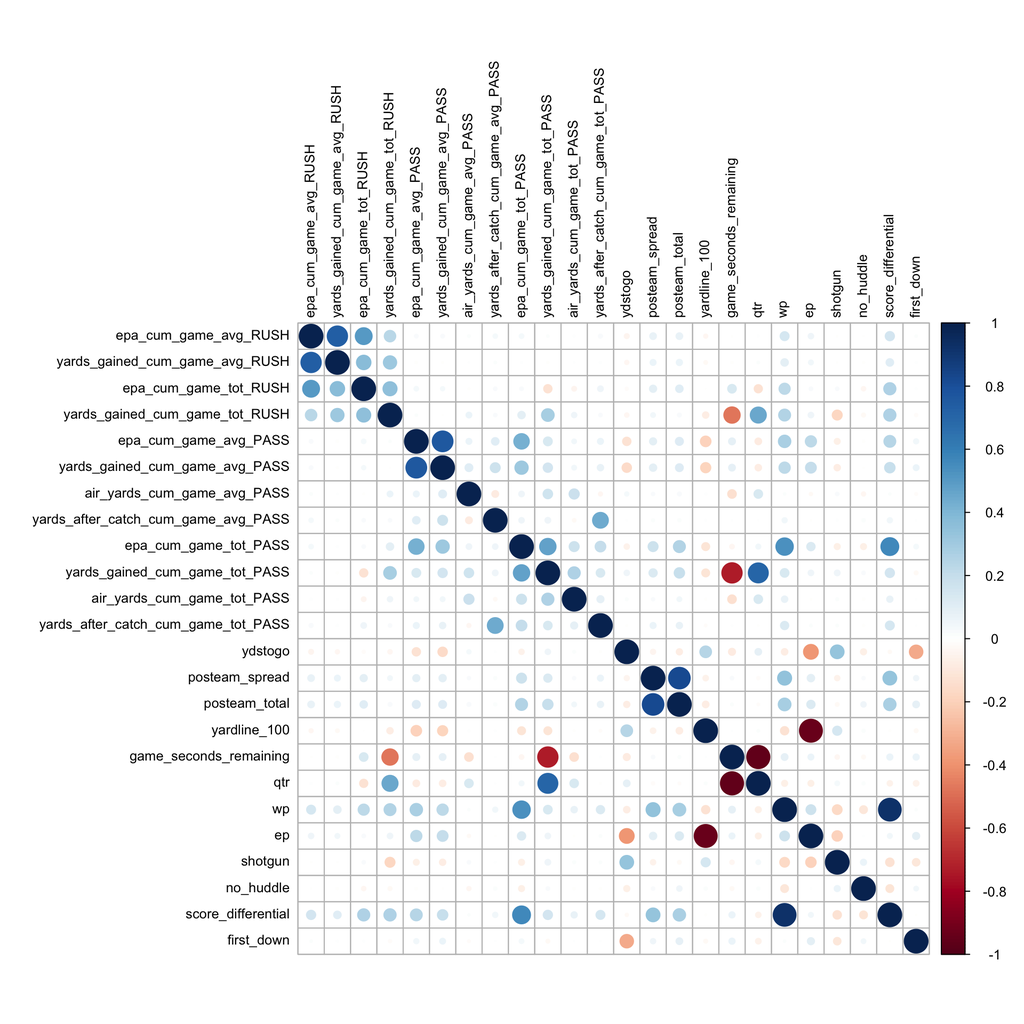

```r
 c <- model_data %>%
  ungroup() %>%
   select(ends_with("_RUSH"),ends_with("_PASS"),

    ydstogo,
    posteam_spread, posteam_total,

    yardline_100,game_seconds_remaining,
    qtr,wp,ep,shotgun,no_huddle,score_differential,

    first_down
    ) %>%
   #na.omit() %>%
   select_if(is.numeric) %>%
   cor(use="complete.obs" )

 corrplot(c,tl.cex=.8,tl.col="black")
```

Yards to go has the strongest correlation with first down conversion rate. As yards to go increases, the probabiliy of converting drops. This is obvious. We can see that the shotgun indicator also has a negative correlation with conversion rate, likely because shotgun and yards to go are also positivley correlated.

There are additional attributes that are strongly correlated with one another.

- Positive correlation between score differential and win probability.
- Negative correlation between yard line 100 and expected points.
- Negative correlation between game seconds remaining and rush/pass yards gained total. As time decreases, total yards over time increases.
- Positive correlations between EPA and total yards gained sum/average fields (both rushes and passes). More yards/higher average yards generally leads to higher EPA.

## Build Models

It is time to build some models using the dataset we created.

These will be classication models that predict if a 3rd or 4th down attempt will result in a first down conversion. The fields we created (cum_game_tot and cum_game_avg fields), and game condition attributes (yards to go, time remaining, yard line, etc.) will be used as inputs to the models.

I use the package h2o for modeling. For more information on h2o, here is their website:

https://www.h2o.ai/

To start with h2o, we need to initiate a cluster.

```r
h2o.init()
```

```
##  Connection successful!
##
## R is connected to the H2O cluster:
##     H2O cluster uptime:         3 hours 48 minutes
##     H2O cluster timezone:       America/Chicago
##     H2O data parsing timezone:  UTC
##     H2O cluster version:        3.32.0.1
##     H2O cluster version age:    6 months and 15 days !!!
##     H2O cluster name:           H2O_started_from_R_joeybloom_ewf057
##     H2O cluster total nodes:    1
##     H2O cluster total memory:   1.10 GB
##     H2O cluster total cores:    8
##     H2O cluster allowed cores:  8
##     H2O cluster healthy:        TRUE
##     H2O Connection ip:          localhost
##     H2O Connection port:        54321
##     H2O Connection proxy:       NA
##     H2O Internal Security:      FALSE
##     H2O API Extensions:         Amazon S3, XGBoost, Algos, AutoML, Core V3, TargetEncoder, Core V4
##     R Version:                  R version 3.6.2 (2019-12-12)
```

```r
h2o.no_progress()
```

#### Split Data

In order to effectively evaluate the models, we must split the data we created into “test” and “train” datasets. Models will be built using the training data and then evaluated against the test data to see how they perform on new data.

In this case, we will train on seasons from 2006 - 2017 and test on seasons from 2018 - 2020.

We also need to convert the “first_down” field to a factor in order for h2o to recognize that this is a classification problem.

```r
## Split train and test data - test on 2018 - 2020 ##
train <- model_data %>% filter(season <= 2017) %>% as.h2o()
test <- model_data %>% filter(season > 2017) %>% as.h2o()

## Make prediction variable factor ##
train$first_down <- as.factor(train$first_down)
```

#### General Linear Model

We will start with a generalized linear model (GLM).

```r
#### BASE GLM ####

## The setdiff command is a way to exclude certain fields from a list. The fields listed below are not included in the model.
## All other attributes will be included.

vars <- setdiff(names(train),c("play_id","game_id","first_down","posteam","season","desc","season_type","down","total_line","outdoors","no_huddle","epa","yards_gained","yards_after_catch","air_yards","qtr","wp","ep","shotgun","rush","pass","team_name","team_id","team_nick","team_color","team_color2","team_color3","team_color4","team_logo_wikipedia","team_logo_espn","team_wordmark"))

cvrt_glm <- h2o.glm(x = vars,
                   y = "first_down",
                   training_frame = train,
                   model_id = "4th_cvrt_glm_fit",
                   nfolds = 10,
                   keep_cross_validation_predictions = TRUE,
                   family = 'binomial',
                   seed=1985)



## training metrics ##
h2o.logloss(cvrt_glm)
```

```
## [1] 0.6335797
```

```r
h2o.auc(cvrt_glm)
```

```
## [1] 0.6759349
```

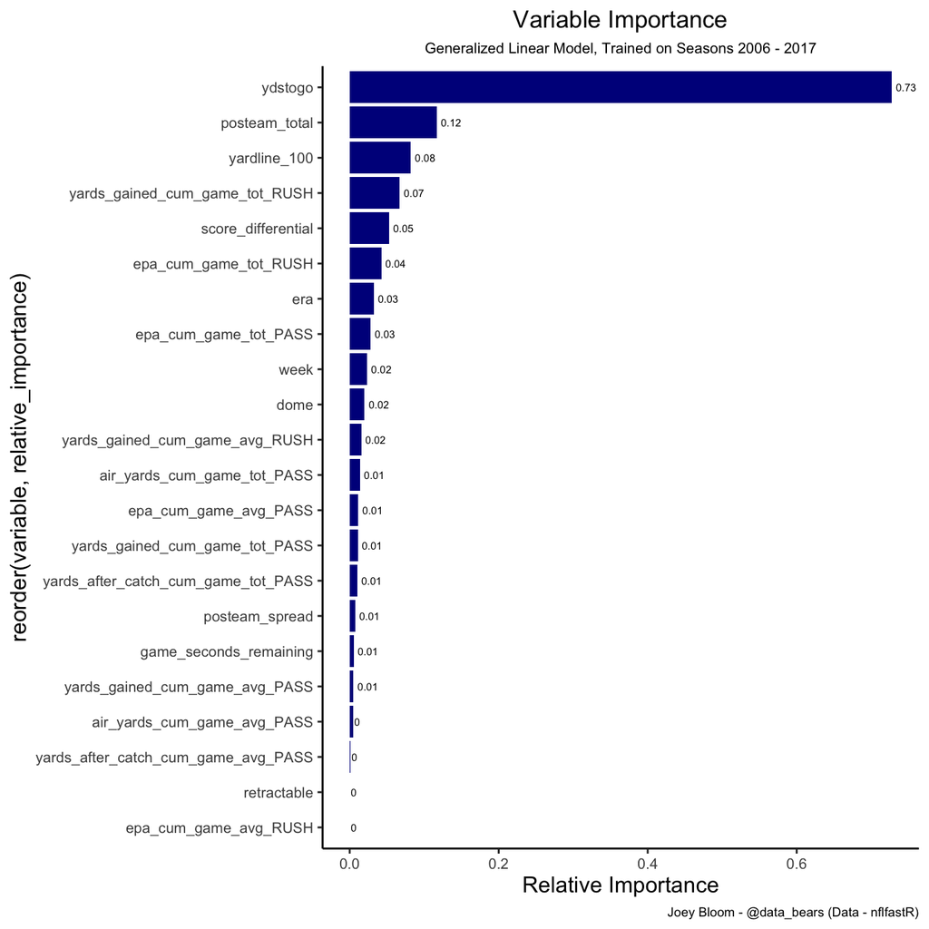

```r
h2o.varimp(cvrt_glm) %>%
  as_tibble() %>%
  ggplot(aes(x = reorder(variable,relative_importance), y = relative_importance)) +
  geom_text(aes(label = round(relative_importance,2)),hjust = -.2,size = 2) +
  geom_bar(stat='identity',fill = 'dark blue') +
  labs(
    title = 'Variable Importance',
    subtitle = 'Generalized Linear Model, Trained on Seasons 2006 - 2017',
    caption = "Joey Bloom - @data_bears (Data - nflfastR)",
    y = "Relative Importance"
  ) +
  coord_flip()
```

##### Train Summary

Yards to go has the most weight in the model by quite a bit. The gap between the next most import feature (GLM relative importance is based on standardized coefficients - source h2o) is over 0.5. The posession team’s estimated total points (posteam_total) is the second most predictive followed by yard line, but they do not come close to yards to go.

Most of the cumulative average and total fields calculated hold little importance, but some are worth noting.

Cumulative total number of rush yards is the 4th most important variable and total EPA on rushes is 6th. It appears that a teams rushing performance within a game does hold some power in predicting if a team will convert. The 8th most important feature is total EPA on pass plays.

##### Test Results

Let’s see how the model performs on our test data.

```r
glm_base_cvrt <- h2o.performance(cvrt_glm,newdata = test)

h2o.logloss(glm_base_cvrt)
```

```
## [1] 0.6273489
```

```r
h2o.auc(glm_base_cvrt)
```

```
## [1] 0.6896629
```

```r
h2o.confusionMatrix(glm_base_cvrt)
```

```
## Confusion Matrix (vertical: actual; across: predicted)  for max f1 @ threshold = 0.314997147254195:
##           0     1    Error         Rate
## 0      4010  8839 0.687913  =8839/12849
## 1      1026  8968 0.102662   =1026/9994
## Totals 5036 17807 0.431861  =9865/22843
```

```r
h2o.accuracy(glm_base_cvrt) %>% arrange(desc(accuracy)) %>% head(5)
```

```
##   threshold  accuracy
## 1 0.4986635 0.6401961
## 2 0.5408302 0.6398897
## 3 0.5379027 0.6397584
## 4 0.4999383 0.6397584
## 5 0.4973165 0.6397146
```

The main metrics I look at are AUC and Log Loss. AUC is a measure for how good the overall model is across many different cutoff points whereas Log Loss helps indicate how correct the model’s prediction was by comparing the true result to the predicted probabilty (using log functions). Good models have high AUC and low Log Loss (both measured between 0 and 1).

For more information, you can refer to this link from the “Hands on Machine Learning with R” book:

https://bradleyboehmke.github.io/HOML/process.html#model-eval

The final results for the GLM model are below:

```
LogLoss:  0.6273489
AUC:      0.68967
```

#### Random Forest

Now onto the Random Forest model (RF).

```r
#### BASE RF ####
vars <- setdiff(names(train),c("play_id","game_id","first_down","posteam","season","desc","season_type","down","total_line","outdoors","no_huddle","epa","yards_gained","yards_after_catch","air_yards","qtr","wp","ep","shotgun","rush","pass","team_name","team_id","team_nick","team_color","team_color2","team_color3","team_color4","team_logo_wikipedia","team_logo_espn","team_wordmark"))

cvrt_rf <- h2o.randomForest(x = vars,
                            y = "first_down",
                            training_frame = train,
                            model_id = "4th_cvrt_rf_fit1",
                            nfolds = 10,
                            keep_cross_validation_predictions = TRUE,
                            seed=1985)
```

```r
## training metrics ##
h2o.logloss(cvrt_rf)
```

```
## [1] 0.6551704
```

```r
h2o.auc(cvrt_rf)
```

```
## [1] 0.6491736
```

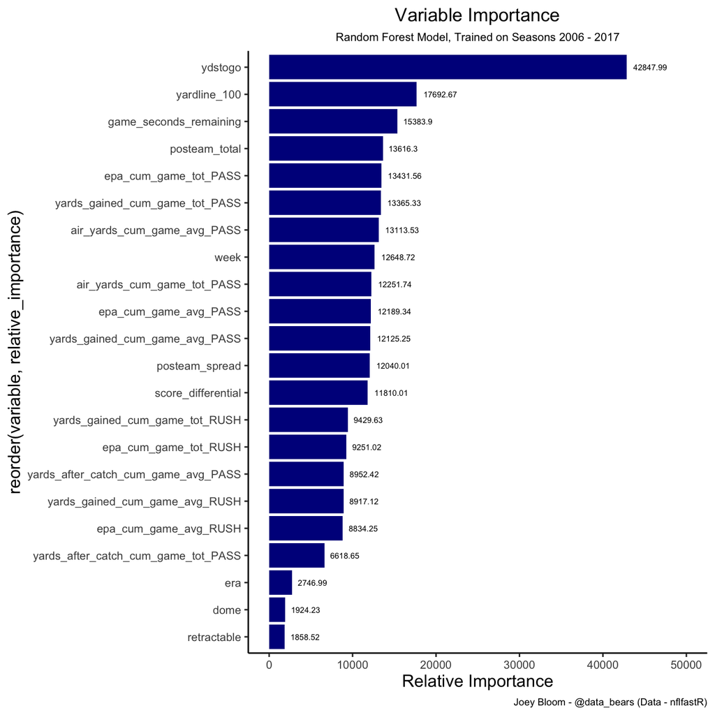

```r
h2o.varimp(cvrt_rf) %>%
  as_tibble() %>%
  ggplot(aes(x = reorder(variable,relative_importance), y = relative_importance)) +
  geom_text(aes(label = round(relative_importance,2)),hjust = -.2,size = 2) +
  geom_bar(stat='identity',fill = 'dark blue') +
  ylim(c(0,50000)) +
  labs(
    title = 'Variable Importance',
    subtitle = 'Random Forest Model, Trained on Seasons 2006 - 2017',
    caption = "Joey Bloom - @data_bears (Data - nflfastR)",
    y = "Relative Importance"
  ) +
  coord_flip()
```

##### Train Summary

Similar to the GLM model, yards to go is the most important feature, with yard line and possession team total being strong predictors as well.

Some differences between the 2 models - game seconds remaining has much more importance in the RF model than it does in the GLM. Additionally, cumulative total passing EPA and yards gained, as well as average air yards hold more weight in the RF model than the GLM. The RF model favors using the passing attributes much more than it does the rushing attributes and these fields also hold a fair amount more importance in the RF model.

Another difference to note between the 2 models is that the RF model is not as dominated by yards to go as the GLM model is. In both models, yards to go is the most important feature by a significant amount, but looking at the graphs, it is clear that the dropoff in importance on the GLM model is larger than it is on the RF model after yards to go. In this case, there is about a 25k difference (RF relative importance is based on whether a field was selected to split on during the tree building process and how much the squared error improved as a result - source h2o) between the top 2 most important fields. It is also worth noting that the other attributes after the top field hold more weight in the RF model than they do in the GLM model.

##### Test Results

Now lets check out the RF model’s performance on the test data.

```r
rf_base_cvrt <- h2o.performance(cvrt_rf,newdata = test)

h2o.logloss(rf_base_cvrt)
```

```
## [1] 0.6371137
```

```r
h2o.auc(rf_base_cvrt)
```

```
## [1] 0.6742929
```

```r
h2o.confusionMatrix(rf_base_cvrt)
```

```
## Confusion Matrix (vertical: actual; across: predicted)  for max f1 @ threshold = 0.344666968559225:
##           0     1    Error         Rate
## 0      4565  8284 0.644719  =8284/12849
## 1      1394  8600 0.139484   =1394/9994
## Totals 5959 16884 0.423675  =9678/22843
```

```r
h2o.accuracy(rf_base_cvrt) %>% arrange(desc(accuracy)) %>% head(5)
```

```
##   threshold  accuracy
## 1 0.4861375 0.6303025
## 2 0.4818286 0.6300836
## 3 0.4890144 0.6300398
## 4 0.4846660 0.6300398
## 5 0.4805102 0.6299523
```

#### Calibration Plots

To make it easier to evaluate each model, I create a function that works with our dataset to create calibration plots inspired by the Yurko et al. paper.

We will use the models to make predictions on the test data and then display the results using the calibration plots.

```r
## Bind test data with model predictions by column
test_preds <- test %>% as_tibble() %>%
  bind_cols(

    ## GLM Predictions ##
    h2o.predict(cvrt_glm,test) %>% as_tibble() %>%
      mutate(prob_fail_glm = p0,
             prob_succeed_glm = p1) %>%
      select(prob_fail_glm,prob_succeed_glm)
  ) %>%
    bind_cols(

    ## RF Predictions ##
    h2o.predict(cvrt_rf,test) %>% as_tibble() %>%
      mutate(prob_fail_rf = p0,
             prob_succeed_rf = p1) %>%
      select(prob_fail_rf,prob_succeed_rf)
  ) %>%
  select(desc,game_id,play_id,season,week,qtr,down,ydstogo,yardline_100,posteam,pass,starts_with("yards_gained_"),
         down,ep,wp,first_down,prob_fail_glm,prob_succeed_glm,prob_fail_rf,prob_succeed_rf,team_logo_espn,team_color,team_color2)


plot_calibration <- function(model_type){

prob_field <-paste0("prob_succeed_",model_type)

test_preds[["prob_field"]] <- test_preds[[prob_field]]

cal_plot <- test_preds %>%
  # Create BINS for wp:
  mutate(bin_pred_prob = round(prob_field / 0.05) * .05) %>%
  group_by(bin_pred_prob) %>%
  # Calculate the calibration results:
  summarize(
    n_plays = n(),
    n_first_downs = length(which(first_down == 1)),
    bin_actual_prob = n_first_downs / n_plays
  ) %>%
  ungroup()

ann_text <- data.frame(
  x = c(.25, 0.75), y = c(0.75, 0.25),
  lab = c("More times\nthan expected", "Fewer times\nthan expected")
)

cal_plot %>%
  ggplot() +
  geom_point(aes(x = bin_pred_prob, y = bin_actual_prob, size = n_plays)) +
  geom_smooth(aes(x = bin_pred_prob, y = bin_actual_prob), method = "loess") +
  geom_abline(slope = 1, intercept = 0, color = "black", lty = 2) +
  coord_equal() +
  scale_x_continuous(limits = c(0, 1)) +
  scale_y_continuous(limits = c(0, 1)) +
  labs(
    size = "Number of plays",
    x = "Estimated Conversion Probability",
    y = "Observed Conversion Probability",
    title = paste0("3rd/4th Down Conversion ",str_to_upper(model_type)," Calibration Plot")
  ) +
  geom_text(data = ann_text, aes(x = x, y = y, label = lab), size = 2) +
  theme_bw() +
  theme(axis.title = element_text(size = 12),
                    axis.text = element_text(size = 8),
                    plot.title = element_text(size = 13, hjust = 0.5),
                    plot.subtitle = element_text(size = 8, hjust = 0.5),
                    plot.caption = element_text(size = 7),
                    legend.position = "none")
}
```

###### GLM

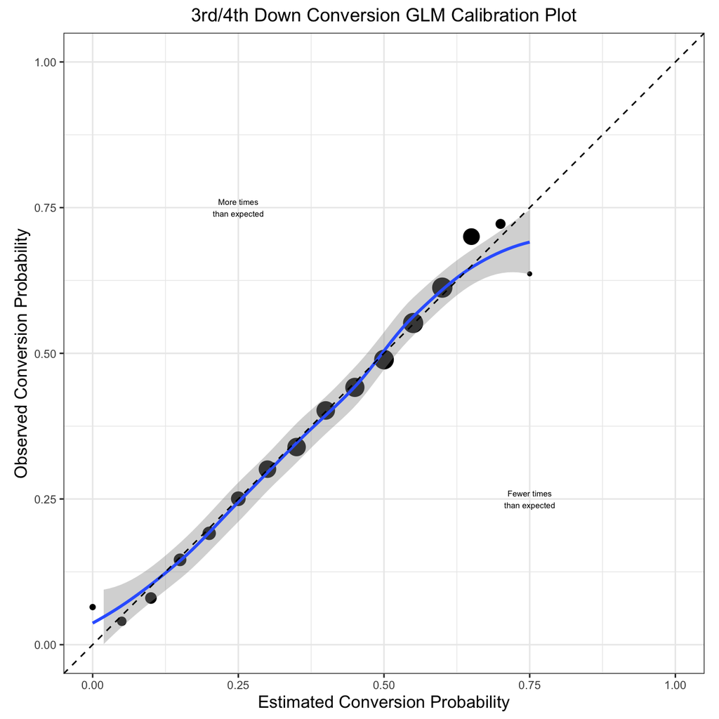

```r
plot_calibration('glm')
```

###### RF

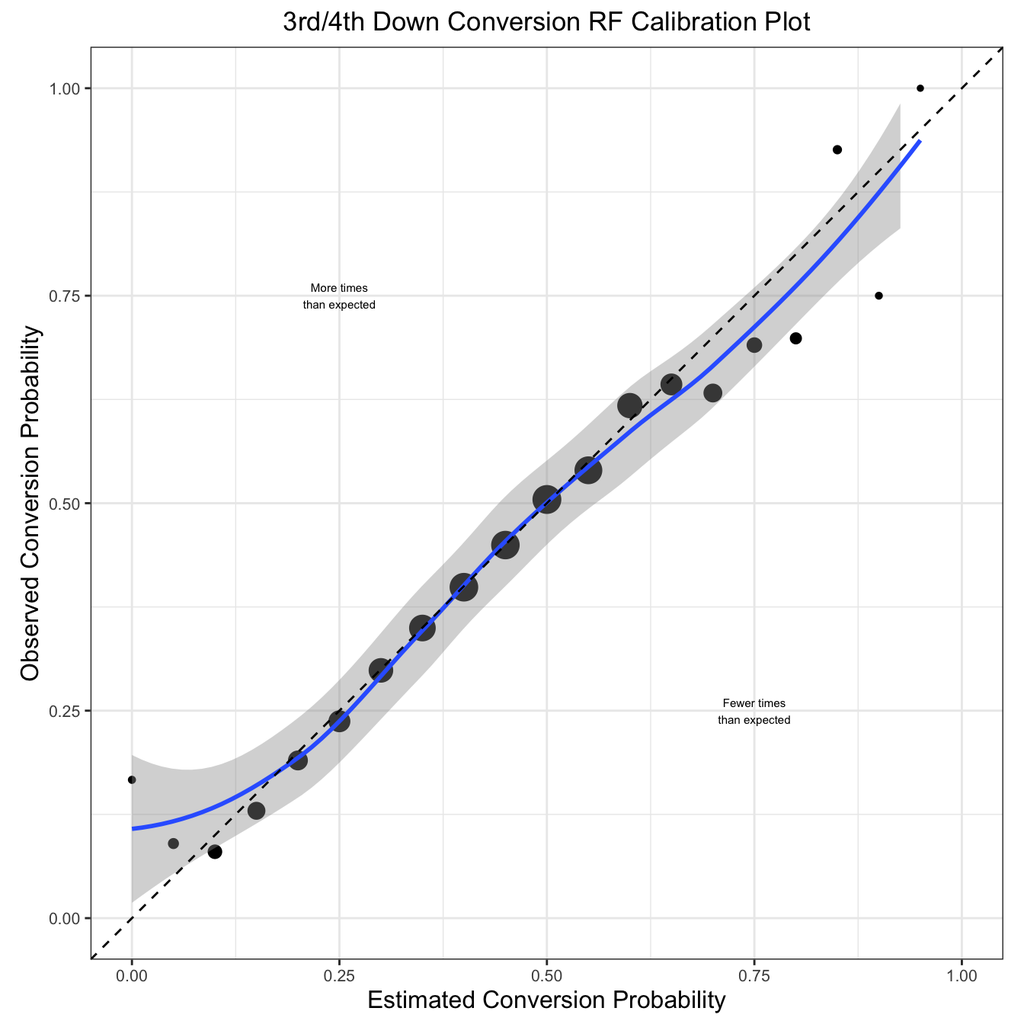

```r
plot_calibration('rf')
```

#### Final Results

The GLM model is performing slightly better than the RF model based on AUC and Log Loss (higher AUC and lower Log Loss).

```
RF:
LogLoss:  0.6371137
AUC:      0.67431

GLM:
LogLoss:  0.6273489
AUC:      0.68967
```

More tuning can be done to improve each model, but for now, let’s take a look at some of the predictions on the test data using the GLM model.

## First Downs Over Expected (FDOE)

In order to evaluate the test data, we will calculate the field “FDOE”, which represents “First Down Over Expected”.

This is calculated by taking the result of the play (first down = 1 or first down = 0) and subtracting the probability the play would result in a first down (0 - 1).

For example: - if a play had a 75% chance of resulting in a first down, and it does result in a first down: fdoe = first_down - prob_succeed => 1 - .75 => .25

- if a play had a 75% chance of resulting in a first down, and it does not result in a first down: fdoe = first_down - prob_succeed => 0 - .75 => -.75

We can take the total FDOE per play by team to get an idea of which teams were good at converting on 3rd/4th downs.

```r
test_preds <- test_preds %>%
  mutate(fdoe_glm = first_down - prob_succeed_glm,
         fdoe_rf  = first_down - prob_succeed_rf)

## Save Predictions
test_preds %>% write.csv("/Users/joeybloom/Desktop/NFLScrapR/GIT/nflfastR/MODELS/Fourth_Down_Convert/SHINY/2018_2020_GLM_FDOE.csv")
```

Using the GLM model, let’s see what First Downs over Expected looks like since 2018 by team.

[figure not shown]

```r
## View Teams by FDOE
plt <- test_preds %>%
  filter(qtr %in% c(1,2,3,4,5),
         season %in% c(2018,2019,2020),
         week >= 1 & week <= 17,
         down %in% c(3,4)) %>%
  group_by(posteam,team_color,team_logo_espn) %>%
  summarise(
    total_fdoe = sum(fdoe_glm),
    avg_fdoe =  mean(fdoe_glm)
  ) %>%
  arrange(desc(total_fdoe)) %>%
  ungroup() %>%
  mutate(label_pos = ifelse(total_fdoe < 0, 2, -2))


## Plot total FDOE by Team
plt %>%
  ggplot(aes(x = reorder(posteam,total_fdoe), y = total_fdoe)) +
  geom_bar(stat='identity',fill = plt$team_color,width = .7) +
  geom_image(aes(x=reorder(posteam,total_fdoe),y=total_fdoe,image = team_logo_espn),asp = 16/9,size=.027) +
  geom_text(aes(x = reorder(posteam,total_fdoe), y = label_pos, label = round(total_fdoe,2)),size = 4) +
  labs(
    title = 'First Downs Over Expected',
    subtitle = '2018 - 2020, Weeks 1-17, Quarters 1-5, 3rd/4th Downs, Rush + Pass Plays, FDOE calculated from Generalized Linear Model',
    caption = "Joey Bloom - @data_bears (Data - nflfastR)",
    y = "Total FDOE"
  ) +
  theme_classic() +
  theme(axis.title = element_text(size = 12),
        axis.text = element_text(size = 8),
        plot.title = element_text(size = 13, hjust = 0.5),
        plot.subtitle = element_text(size = 8, hjust = 0.5),
        plot.caption = element_text(size = 7),
        legend.position = "none",
        axis.title.y=element_blank(),
        axis.text.y=element_blank(),
        axis.ticks.y=element_blank()) +
  coord_flip()
```

##### Team Results

Bears fans, shield your eyes!

Since 2018, in the regular season, Chicago ranks 4th worst in FDOE throughout the league with a total of -14.75.

On the contrary, Baltimore ranks the highest with a total of 36.49 holding a fairly large gap above the next best team (ATL - 26.99).

Surprisingly (at least to me), New England has the 2nd worst FDOE with -21.76 total FDOE.

Half of the teams in the league have an FDOE above 0 since 2018.

To play around with these results some more, visit this Shiny Dashboard below:

https://nflpredictor.shinyapps.io/3rd_4th_converter/

Let’s take a look at each team’s average probability of converting verses their total FDOE.

[figure not shown]

```r
avg <- test_preds %>%
  filter(qtr %in% c(1,2,3,4,5),
         season %in% c(2018,2019,2020),
         week >= 1 & week <= 17,
         down %in% c(3,4)) %>%
  group_by(team_logo_espn,posteam) %>%
  summarize(
    avg_yds_togo = mean(ydstogo),
    avg_pass = mean(pass),
    avg_total_rush_yds_gained = mean(yards_gained_cum_game_tot_RUSH,na.rm=TRUE),
    avg_prob_succeed = mean(prob_succeed_glm),
    total_fdoe = sum(fdoe_glm)
  )




avg %>%
  ggplot(aes(x = total_fdoe, y = avg_prob_succeed)) +
  geom_image(aes(x = total_fdoe, y = avg_prob_succeed,image = team_logo_espn),asp = 16/9,size=.027) +
  geom_hline(yintercept = mean(avg$avg_prob_succeed), color = 'red', linetype = 'dotted') +
  geom_vline(xintercept = mean(avg$total_fdoe), color = 'red', linetype = 'dotted') +
  labs(
    x = "Total FDOE",
    y = 'Average Prob Convert',
    title = 'Average Probability of Converting vs Total FDOE',
    subtitle = '2018 - 2020, Weeks 1-17, Quarters 1-5, 3rd/4th Downs, Rush + Pass Plays, FDOE/Avg Prob Convert calculated from Generalized Linear Model',
    caption = "Joey Bloom - @data_bears (Data - nflfastR)"
  ) +
  theme_classic() +
  theme(axis.title = element_text(size = 12),
        axis.text = element_text(size = 8),
        plot.title = element_text(size = 13, hjust = 0.5),
        plot.subtitle = element_text(size = 8, hjust = 0.5),
        plot.caption = element_text(size = 7),
        legend.position = "none")
```

Comparing the best and the worst teams in FDOE, Baltimore puts themselves in much better situations on 3rd/4th downs compared to the Jets. Baltimore’s average probability of converting is above the average whereas the Jets’ rank last.

What makes Baltimore’s situations that much better than the Jets? We can look at the average pass rate versus yards to go for each team.

[figure not shown]

```r
avg %>%
  ggplot(aes(x = avg_yds_togo, y = avg_pass)) +
  geom_smooth(aes(x = avg_yds_togo, y = avg_pass), method = "lm") +
  geom_image(aes(x = avg_yds_togo, y = avg_pass,image = team_logo_espn),asp = 16/9,size=.027) +
  geom_hline(yintercept = mean(avg$avg_pass), color = 'red', linetype = 'dotted') +
  geom_vline(xintercept = mean(avg$avg_yds_togo), color = 'red', linetype = 'dotted') +
  labs(
    y = "Pass Rate",
    x = 'Average Yards to Go',
    title = 'Average Pass Rate vs Average Yards to Go',
    subtitle = '2018 - 2020, Weeks 1-17, Quarters 1-5, 3rd/4th Downs, Rush + Pass Plays, FDOE calculated from Generalized Linear Model',
    caption = "Joey Bloom - @data_bears (Data - nflfastR)"
  ) +
  theme_classic() +
  theme(axis.title = element_text(size = 12),
        axis.text = element_text(size = 8),
        plot.title = element_text(size = 13, hjust = 0.5),
        plot.subtitle = element_text(size = 8, hjust = 0.5),
        plot.caption = element_text(size = 7),
        legend.position = "none")
```

Baltimore is well below the league average in yards to go on 3rd/4th downs whereas the Jets rank near the bottom. There is a trend between pass rate and yards to go, and Baltimore has the lowest pass rate (highest rush rate) by far throughout the league. Wonder why Baltimore’s rush rate is so high? We can assess how good they are on rush plays.

[figure not shown]

```r
avg %>%
  ggplot(aes(x = avg_pass, y = avg_total_rush_yds_gained)) +
  geom_smooth(aes(x = avg_pass, y = avg_total_rush_yds_gained), method = "lm") +
  geom_image(aes(x = avg_pass, y = avg_total_rush_yds_gained,image = team_logo_espn),asp = 16/9,size=.027) +
  geom_hline(yintercept = mean(avg$avg_total_rush_yds_gained), color = 'red', linetype = 'dotted') +
  geom_vline(xintercept = mean(avg$avg_pass), color = 'red', linetype = 'dotted') +
  labs(
    x = "Pass Rate",
    y = 'Average Total Rush Yards Gained',
    title = 'Average Total Rush Yards Gained vs Pass Rate',
    subtitle = '2018 - 2020, Weeks 1-17, Quarters 1-5, 3rd/4th Downs, Rush + Pass Plays, FDOE calculated from Generalized Linear Model',
    caption = "Joey Bloom - @data_bears (Data - nflfastR)"
  ) +
  theme_classic() +
  theme(axis.title = element_text(size = 12),
        axis.text = element_text(size = 8),
        plot.title = element_text(size = 13, hjust = 0.5),
        plot.subtitle = element_text(size = 8, hjust = 0.5),
        plot.caption = element_text(size = 7),
        legend.position = "none")
```

Baltimore is not passing that much on 3rd/4th down because they perform so well on the rush. They by far have the highest average “Total Rush Yards Gained” throughout the league and we can see a clear trend between pass rate on 3rd/4th down and average “Total Rush Yards Gained”. When a team is rushing the ball well, their pass rate generally will decrease on 3rd/4th downs.

## Summary

For my first model in the NFL world, there are a couple of takeaways I have from this and some next steps.

Though it probably was obvious, yards to go is the biggest predictor in whether or not the result will be a first down. It also appears that using some form of moving averages and/or cumulative sums to track in game stats can help improve the model.

The initial findings on the 2018-2020 seasons help shed some light on who did well and who struggled on 3rd/4th downs relative to what was expected. Baltimore has been converting on 3rd/4th down at a rate much higher than expected whereas the Jets are the exact opposite. Much of this is contributed to the position each team finds themselves on 3rd/4th down (easy versus hard to convert), and in Baltimore’s case, their rushing success.

Some next steps to enhance what has been done here would looking to refine the in game stats, for example, looking back at “N” plays instead of the whole game (IE, avg yards gained on previous 3/5/10 plays). It would also be useful to look at early downs to see what kind of decisions teams are making and how the play results impact their probality of converting on 3rd/4th down. We could look at FDOE for individual players to get a better understanding of a team’s FDOE or look at which defenses are most effective on 3rd/4th downs. Additionally, just like the 4th down model from Ben Baldwin that inspired this article, this model could be used within a larger framework to help make decisions about what to do on 4th downs.

If you got this far, thank you so much for reading through and I hope you got something meaningful from this!

Any and all feedback is much appreciated! Shoutout to Ben Baldwin and the whole nflfastR/twitter analytics community. If you see a hole in the logic or have any criticism, please feel free to reach out!

*written by Joey Bloom (@data_bears)*

*data from nflfastR*

*modeled after Ben Baldwin’s nfl4th model (@BenBaldwin)*